# Fitting Generalized Additive Models

3 June 2026

## Acknowledgements

Gavin Simpson and colleagues have produced a lot of useful teaching material on GAMs that I’ve made use of here. For example:

- https://www.youtube.com/watch?v=sgw4cu8hrZM&t=598s
- https://www.youtube.com/watch?v=Ukfvd8akfco&t=905s

## Goals for today

- Understand some diagnostics
- Understand more about model selection techniques with GAMs
- Become familiar with some of the flexibility of GAMs

## Last time

A generalized additive model is a generalization of a GLM. It has a predictor that is a sum of smoothed (and possibly unsmoothed) terms:

\[ y_i = \beta_0 + \Sigma_j s_j(x_{j,i}) + \epsilon_j \]

And with splines, our smoothed terms are a sum of weighted basis functions:

\[ s(x)=\Sigma_k \beta_k b_k(x) \]

## Model choices

Based on understanding of your system:

- error distribution
- predictors
- type of smoother(s)

Check with diagnostics

- **\(k\) - the number of knots**

## An example

Chicago pollution and death rate (Peng et al.; NMMAPSdata package)

- deaths per day
- median particles <2.5 mg per \(m^3\)
- ozone ppb
- temperature (fahrenheit)

```r
data(chicago, package = "gamair")

model1 <- mgcv::gam(death ~ s(pm25median) +
                      s(o3median) +
                      s(tmpd),
                    family = "poisson",
                    data=chicago, method = "REML")
```

## An example

Smoothed Terms

```
##                    edf   Ref.df     Chi.sq      p-value
## s(pm25median) 3.518573 4.440907  20.860574 0.0006254809
## s(o3median)   3.430259 4.305665   6.373377 0.2230510318
## s(tmpd)       4.801666 5.878771 244.698414 0.0000000000
```

## GAM interpretation

- Effective degrees of freedom (edf) - degree of non-linearity, but with upper bound set by \(k\)
- Reference degrees of freedom (Ref.df) - used for calculating test statistic
- \(p\)-value - null hypothesis is a linear effect (this can include a flat linear effect, i.e., no effect)
  - Biased low because they don’t account for need to estimate \(\lambda\)
  - Works well in asymptopia
  - Doesn’t work for unpenalized smooths (random effects)

## Model checking

- Effect of \(k\) on edf (for median particles <2.5 mg per \(m^3\))

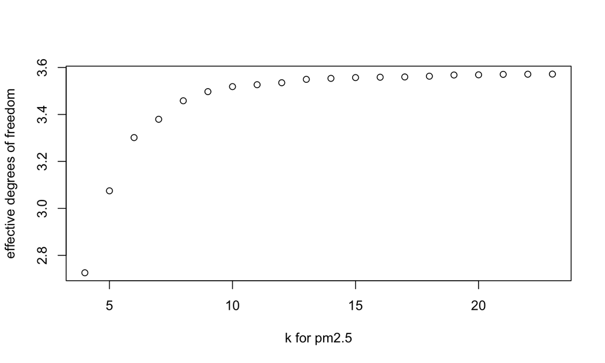

## Model checking

- Check whether \(k\) is adequate - can set it very large to start, but this increases computation time
- Do some iterative checking with larger values of \(k\) for multiple parameters, effective degrees of freedom should stabilize

```r
gam.check(model1)
```

## Model checking

With \(k\) set to default for each variable: check \(p\)-values

```
##
## Method: REML   Optimizer: outer newton
## full convergence after 4 iterations.
## Gradient range [-7.763319e-07,1.839545e-08]
## (score 2867.802 & scale 1).
## Hessian positive definite, eigenvalue range [0.2056908,1.115369].
## Model rank =  28 / 28
##
## Basis dimension (k) checking results. Low p-value (k-index<1) may
## indicate that k is too low, especially if edf is close to k'.
##
##                 k'  edf k-index p-value
## s(pm25median) 9.00 3.52    0.99   0.335
## s(o3median)   9.00 3.43    0.97   0.230
## s(tmpd)       9.00 4.80    0.94   0.085 .
## ---
## Signif. codes:  0 '***' 0.001 '**' 0.01 '*' 0.05 '.' 0.1 ' ' 1
```

## Model checking

With \(k\) set to 20 for each variable

```r
model1 <- mgcv::gam(death ~ s(pm25median, k=20) +
                      s(o3median, k=20) +
                      s(tmpd, k=20),
                    family = "poisson",
                    data=chicago, method = "REML")

gam.check(model1)
```

## Model checking

With \(k\) set to 20 for each variable: \(p\)-value above \(\alpha\), and edf is not close to \(k\)

```
##
## Method: REML   Optimizer: outer newton
## full convergence after 3 iterations.
## Gradient range [-1.827205e-06,5.041726e-07]
## (score 2867.819 & scale 1).
## Hessian positive definite, eigenvalue range [0.1852984,1.155305].
## Model rank =  58 / 58
##
## Basis dimension (k) checking results. Low p-value (k-index<1) may
## indicate that k is too low, especially if edf is close to k'.
##
##                  k'   edf k-index p-value
## s(pm25median) 19.00  3.57    0.99    0.32
## s(o3median)   19.00  3.59    0.97    0.22
## s(tmpd)       19.00  5.01    0.94    0.08 .
## ---
## Signif. codes:  0 '***' 0.001 '**' 0.01 '*' 0.05 '.' 0.1 ' ' 1
```

## Model checking

- We need to check the other assumptions of our model as well
- gam.check() also provides some basic diagnostic plots

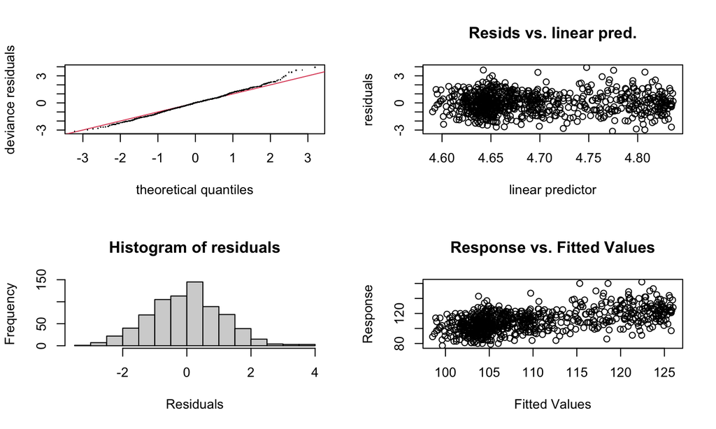

```
##
## Method: REML   Optimizer: outer newton
## full convergence after 3 iterations.
## Gradient range [-1.827205e-06,5.041726e-07]
## (score 2867.819 & scale 1).
## Hessian positive definite, eigenvalue range [0.1852984,1.155305].
## Model rank =  58 / 58
##
## Basis dimension (k) checking results. Low p-value (k-index<1) may
## indicate that k is too low, especially if edf is close to k'.
##
##                  k'   edf k-index p-value
## s(pm25median) 19.00  3.57    0.99    0.31
## s(o3median)   19.00  3.59    0.97    0.22
## s(tmpd)       19.00  5.01    0.94    0.06 .
## ---
## Signif. codes:  0 '***' 0.001 '**' 0.01 '*' 0.05 '.' 0.1 ' ' 1
```

## Model selection

- When we select \(\lambda\) we are only penalizing wiggliness, thus only penalizing functions of \(X\) with a second derivative that is >0
- Linear relationships can’t be removed from the model this way

## Model selection

In gam(), we can use “select=TRUE” to apply penalties to the linear terms as well

```r
model1 <- mgcv::gam(death ~ s(pm25median, k = 20) +
                      s(o3median, k = 20) +
                      s(tmpd, k = 20),
                    family = "poisson", select = TRUE,
                    data=chicago, method = "REML")
```

## Model selection

Look to see if edf is less than 1

```
##                       edf Ref.df       Chi.sq      p-value
## s(pm25median) 3.190343018     19 2.386213e+01 1.016769e-05
## s(o3median)   0.001727235     19 8.919134e-04 5.291635e-01
## s(tmpd)       4.414165057     19 3.391034e+02 0.000000e+00
```

## Model selection

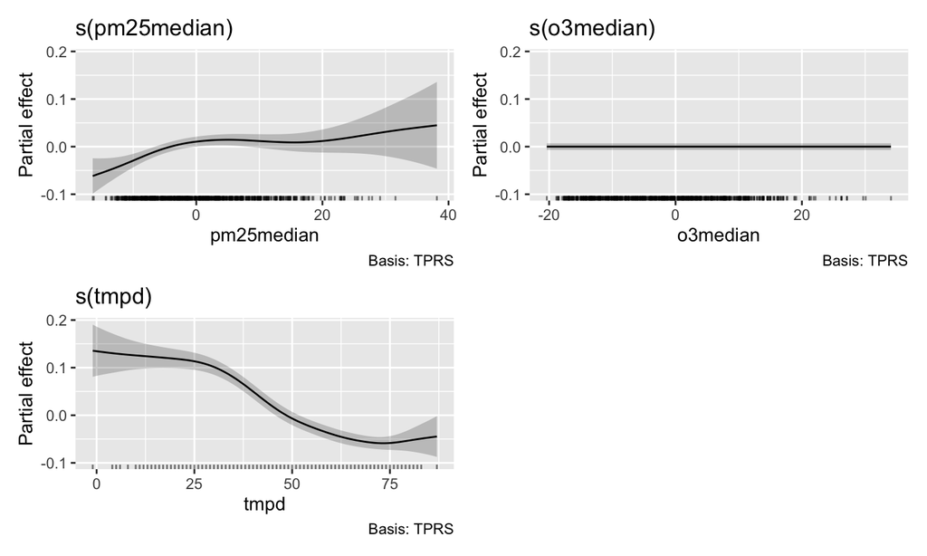

## Flexibility of GAMs

- We have lots of options when fitting GAMs
- This flexibility means we have to give very careful thought to what we’re trying to achieve
- Just because we can fit a GAM doesn’t mean it will be interpretable or useful

## Example

Atmospheric carbon dioxide data (measured at the South Pole) since 1957 to ~1999

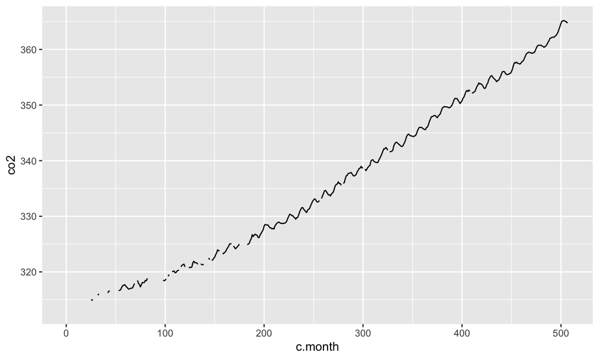

## Example

Using the cubic regression basis - better when we have a lot of wiggliness

Make \(k\) large (lots of potential wiggliness)

```r
b <- gam(co2 ~ s(c.month, k=300, bs="cr"), data = co2s, method = 'REML')
```

## Example

```
##
## Family: gaussian
## Link function: identity
##
## Formula:
## co2 ~ s(c.month, k = 300, bs = "cr")
##
## Parametric coefficients:
##              Estimate Std. Error t value Pr(>|t|)
## (Intercept) 3.382e+02  4.444e-03   76111   <2e-16 ***
## ---
## Signif. codes:  0 '***' 0.001 '**' 0.01 '*' 0.05 '.' 0.1 ' ' 1
##
## Approximate significance of smooth terms:
##              edf Ref.df     F p-value
## s(c.month) 205.3  241.4 44646  <2e-16 ***
## ---
## Signif. codes:  0 '***' 0.001 '**' 0.01 '*' 0.05 '.' 0.1 ' ' 1
##
## R-sq.(adj) =      1   Deviance explained =  100%
## -REML = 36.492  Scale est. = 0.0084334  n = 427
```

## Example

Now try to predict from the model

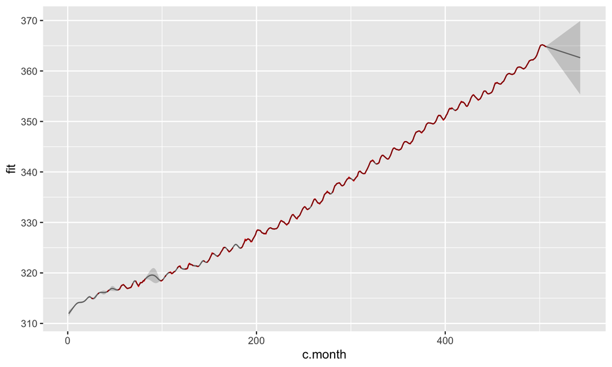

## Example

We fit a model, but it isn’t particularly interpretable or useful

Let’s distinguish within-year variation from the long-term trend

- Fit a cyclic spline on month (1:12) and a cubic regression spline on cumulative month (1:507)

```r
b2 <- gam(co2 ~ s(month, bs = "cc") +
            s(c.month, bs = "cr", k = 300),
            knots = list(month = c(0.5, 12.5)),
            data = co2s, method = 'REML')
```

## Example

```
##
## Family: gaussian
## Link function: identity
##
## Formula:
## co2 ~ s(month, bs = "cc") + s(c.month, bs = "cr", k = 300)
##
## Parametric coefficients:
##              Estimate Std. Error t value Pr(>|t|)
## (Intercept) 3.382e+02  5.331e-03   63447   <2e-16 ***
## ---
## Signif. codes:  0 '***' 0.001 '**' 0.01 '*' 0.05 '.' 0.1 ' ' 1
##
## Approximate significance of smooth terms:
##                edf Ref.df       F p-value
## s(month)     7.266    8.0   165.1  <2e-16 ***
## s(c.month) 107.309  131.8 56450.2  <2e-16 ***
## ---
## Signif. codes:  0 '***' 0.001 '**' 0.01 '*' 0.05 '.' 0.1 ' ' 1
##
## R-sq.(adj) =      1   Deviance explained =  100%
## -REML = -103.74  Scale est. = 0.012136  n = 427
```

## Example

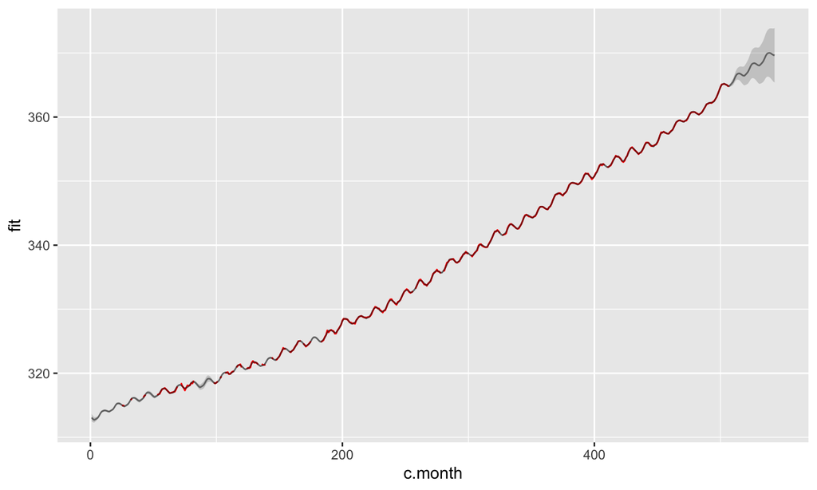

## Example

- The second model seems more interpretable (there is predictable annual variation, but also a long-term pattern) and is more useful for prediction
- Building GAMs is more complex than building GLMs because we have more choices
- Requires thinking hard about the system and the question

## Options for interactions

In addition to splines on individual predictors, we can fit interactions

- te(x1,x2) - main effects and interactions - separate smoothness parameter and separate marginal basis
- ti(x1,x2) - interactions only - for when you have the main effect elsewhere in the model (for example, if you have multiple two-way interactions, a*b + a*c + b*c)
- s(x1,x2, bs = ‘tp’) - bivariate thin plate splines - single smoothness parameter, only use when units are the same (e.g., spatial smoother)
- f + s(x1, by = f) - when we want to smooth by different levels of a factor (be sure you include the factor as a fixed effect)
- s(x, f, bs = ‘fs’) - smooth function for each level of the factor, akin to random slopes

## Mixed Models

We can also fit random effects

- mgcv:gam() with bs = “re”
- mgcv:gamm() - nlme - with correlation structures
- gamm4:gamm4() - lmer() or glmer()

Thus, these models are equivalent:

- lme(y ~ 1 + (1|f), method = “REML”)
- gam(y ~ s(f, bs = “re”), method = “REML”)

## Summary

- GAMs using splines offer tremendous flexibility
- There is likely some tradeoff between flexibility and ease of understanding
- Many of our relationships in ecology aren’t linear
- What are some examples?